# Story_5

Alex Khaykin

2023-11-01

### INTRODUCTION

Historic data seems to indicate the average temperature on earth has been increasing over tome. Further, it has been widely reported and believed that the increase in global temperature is responsible for the increased severity, intensity, and occurrence of cyclonic storms (Hurricanes, Typhoons, and Tornadoes). For this assignment I will utilize NYC average temperatures from The Climate explorer 1950 through 2013. As well as count of Tornadoes occurrences from The National Centers for Environmental Information, the count of Hurricane occurrences from United States Environmental Protection Agency, Tornadoes intensity from NOAA National Weather Services, and Hurricane intensity from NOAA Hurricane Research Division. I will attempt to let the data tell the story if indeed the Global temperature has had an effect on occurrence and intensity of these storms.

```r
library(tidyverse)
```

```r
library(ggplot2)
```

Reading in the data.

```r
tornadoes <- read.csv("~/DATA_SCIENCE/DATA_608/Major Assignments/Assingment_5/DATA/tornadoes.csv")
tropical_cyclones <- read.csv("~/DATA_SCIENCE/DATA_608/Major Assignments/Assingment_5/DATA/tropical_cyclones.csv")
temp <- read.csv("~/DATA_SCIENCE/DATA_608/Major Assignments/Assingment_5/DATA/New_York_County-annual-hist_obs-tmax.csv")
h_intensity <- read.csv("~/DATA_SCIENCE/DATA_608/Major Assignments/Assingment_5/DATA/hurricane_intensity_by_year.csv")
t_intensity <- read.csv("~/DATA_SCIENCE/DATA_608/Major Assignments/Assingment_5/DATA/1950-2022_tornados_intensity.csv")
```

Grouping the intensity of Hurricane and Tornadoes data data by year, summarizing the intensity, and joining to create one intensity dataset.

```r
h_intensity_summ <- h_intensity %>%
  group_by(Year) %>%
  summarise(Avg_SS_index = mean(Highest.Saffir.Simpson.US.Category), Hurricanes = n())
t_intensity_summ <- t_intensity %>%
  rename(Year = yr) %>%
  group_by(Year) %>%
  summarise(Avg_F_index = mean(mag, na.rm = TRUE), Tornadoes = n())
intensities <- h_intensity_summ %>%
  inner_join(t_intensity_summ, join_by(Year))
```

To merge the Hurricane and Tornado count datasets.

```r
tornadoes <- tornadoes %>%
  rename(Year = Date)
merged <- tornadoes %>%
  inner_join(tropical_cyclones, join_by(Year))
temp <- temp %>%
  rename(Year = year)
merged2 <- merged %>%
  inner_join(temp, join_by(Year))
```

To pivot table longer for graphing.

```r
data_long <- merged2 %>%
  select(Year, tmax, Tornadoes, Hurricanes.reaching.the.United.States) %>%
  pivot_longer(cols = !c(Year, tmax), names_to = "Storm", values_to = "count") %>%
  mutate(Storm = ifelse(Storm == "Tornadoes", "Tornadoes", "Hurricanes"))
```

Plotting the landfall frequency storms over time from 1950 through 2013.

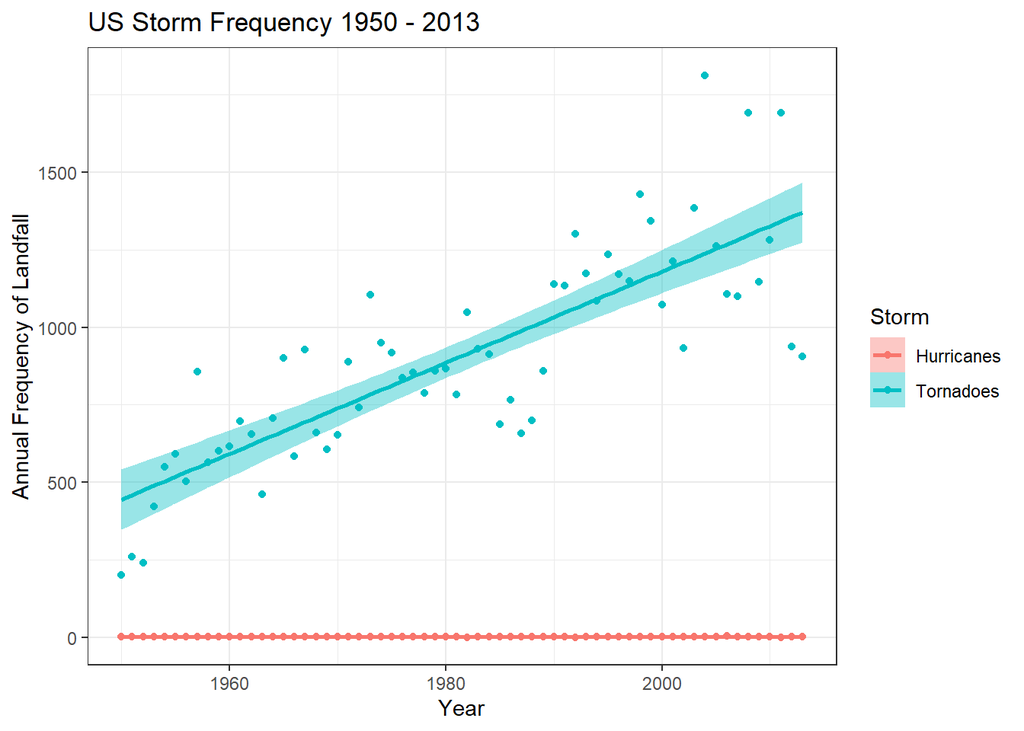

```r
data_long %>%
  ggplot(aes(x = Year, y = count, fill = Storm, color = Storm)) +
  geom_point() +
  geom_smooth(method = "lm") +
  labs(x = "Year", y = "Annual Frequency of Landfall", title = "US Storm Frequency 1950 - 2013") +
  theme_bw()
```

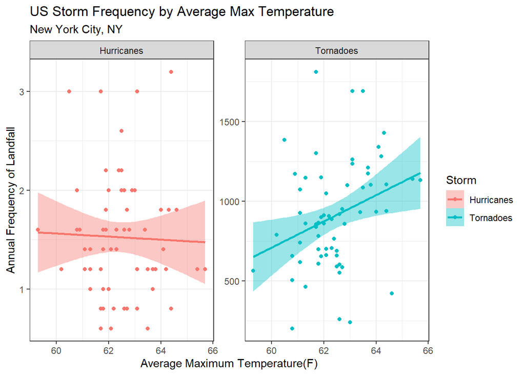

```r
data_long %>%
  ggplot(aes(x = tmax, y = count, fill = Storm, color = Storm)) +
  geom_point() +
  geom_smooth(method = "lm") +
  labs(x = "Average Maximum Temperature(F)", y = "Annual Frequency of Landfall", title = "US Storm Frequency by Average Max Temperature", subtitle = "New York City, NY") +
  theme_bw() +
  facet_wrap(~Storm, scales = "free")
```

Plotting the average Maximum temperate over time from 1950 through 2013.

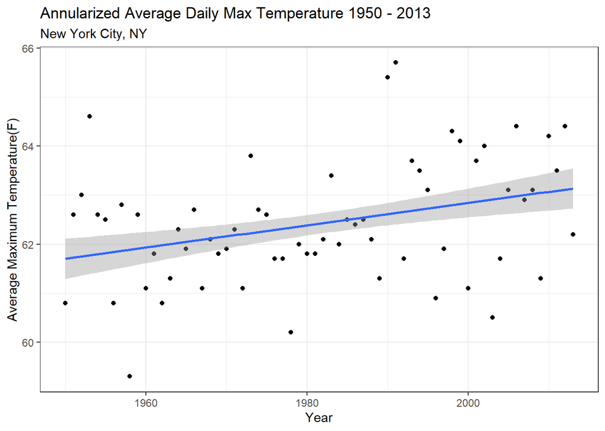

```r
data_long %>%
  ggplot(aes(x = Year, y = tmax)) +
  geom_point() +
  geom_smooth(method = "lm") +
  labs(x = "Year", y = "Average Maximum Temperature(F)", title = "Annularized Average Daily Max Temperature 1950 - 2013", subtitle = "New York City, NY") +
  theme_bw()
```

Plotting the landfall frequency of storms from 1950 though 2013.

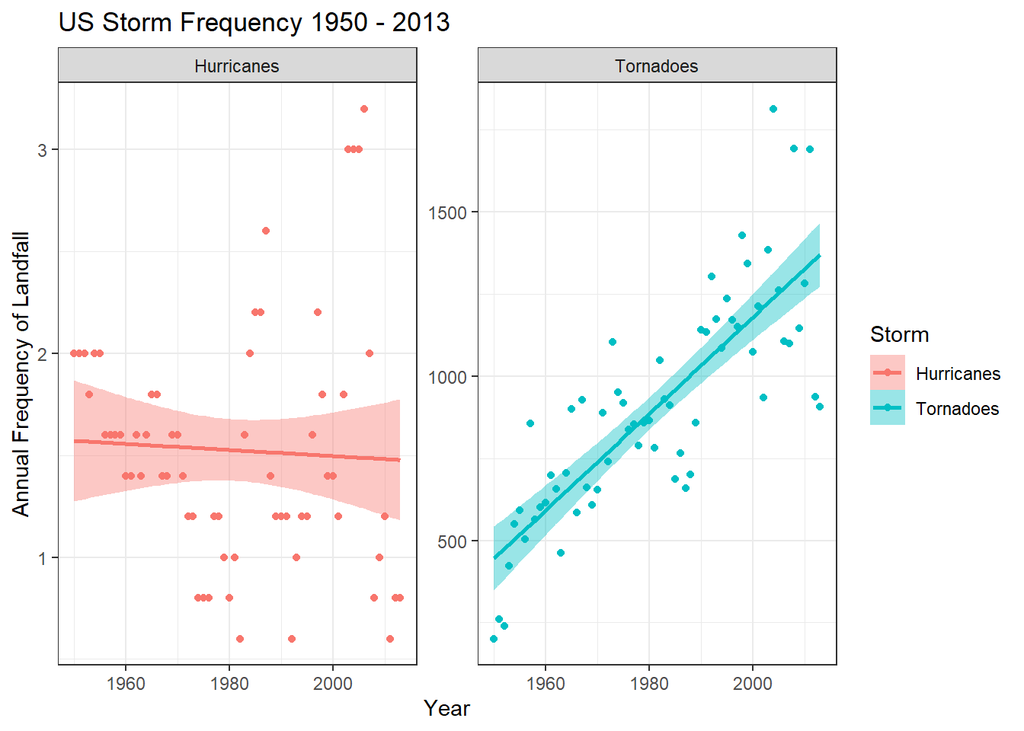

```r
data_long %>%
  ggplot(aes(x = Year, y = count, fill = Storm, color = Storm)) +
  geom_point() +
  geom_smooth(method = "lm") +
  labs(x = "Year", y = "Annual Frequency of Landfall", title = "US Storm Frequency 1950 - 2013") +
  theme_bw() +
  facet_wrap(~Storm, scales = "free")
```

Data wrangling for the combined intensities datasets into one.

```r
intensities_long <- intensities %>%
  pivot_longer(cols = !c(Year, Hurricanes, Tornadoes), names_to = "Scale", values_to = "Value") %>%
  mutate(Scale = ifelse(Scale == "Avg_F_index", "Tornadoes (Fujita)", "Hurricanes (Saffir-Simpson)"))
```

Plotting the US Storm intensity data from 1950 through 2022.

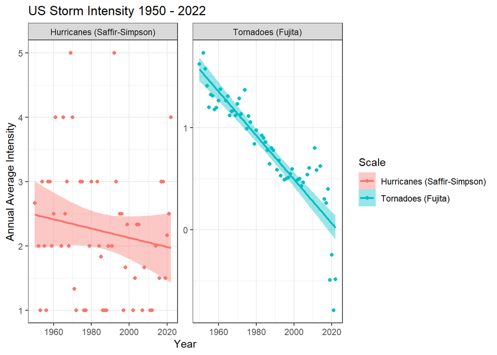

```r
intensities_long %>%
  ggplot(aes(x = Year, y = Value, fill = Scale, color = Scale)) +
  geom_point() +
  geom_smooth(method = "lm") +
  labs(x = "Year", y = "Annual Average Intensity", title = "US Storm Intensity 1950 - 2022") +
  theme_bw() +
  facet_wrap(~Scale, scales = "free")
```

#### SOURCES

**Tornadoes Count** https://www.ncei.noaa.gov/access/monitoring/tornadoes/time-series/ytd/12?mean=true

**Hurricane Counts** https://www.epa.gov/climate-indicators/climate-change-indicators-tropical-cyclone-activity

**Tornado Intensity** https://www.spc.noaa.gov/wcm/

**Hurricane Intensity** https://www.aoml.noaa.gov/hrd/hurdat/All_U.S._Hurricanes.html

**Average Maximum NYC Temp over time** https://crt-climate-explorer.nemac.org/climate_graphs/?county=New+York+County&city=New+York%2C+NY&fips=36061&lat=40.7127753&lon=-74.0059728